# Exploratory analysis of the secondary dataset

2017-11-15

```r
rm(list = ls())
library(tidyverse); library(ggthemes); library(kableExtra); library(knitr); library(viridis); library(readxl); library(stringr)
projectData <- read_csv("../../../Data Cleaning/Secondary Data/Projects/Data/Temp Files/projectsFinal.csv")
#snlData <- read_csv("../../Data/Secondary Data/Projects/Data/Temp Files/secondaryProjectData.csv")
snlCmdtyLocData <- read_excel("../../../Data Cleaning/Secondary Data/Projects/Data/Secondary data sources/snl_all_comdty_location.xls", sheet = 1) %>%
    mutate_at(16:17, as.character) %>%
    bind_rows(., read_excel("../../../Data Cleaning/Secondary Data/Projects/Data/Secondary data sources/snl_all_comdty_location_inactive.xls", sheet = 1)) %>%
    select(-(`Property Name`))
```

```r
snlOwnership <- read_excel("../../../Data Cleaning/Secondary Data/Projects/Data/Secondary data sources/snl_ownership.xls", sheet = 1) %>%
    bind_rows(., read_excel("../../../Data Cleaning/Secondary Data/Projects/Data/Secondary data sources/snl_ownership_inactive.xls", sheet = 1)) %>%
    select(-(`Property Name`))
snlFinancing <- read_excel("../../../Data Cleaning/Secondary Data/Projects/Data/Secondary data sources/snl_financing.xls", sheet = 1) %>%
    bind_rows(., read_excel("../../../Data Cleaning/Secondary Data/Projects/Data/Secondary data sources/snl_financing_inactive.xls", sheet = 1)) %>%
    gather(key = "round", value = "amt", -(1:2)) %>%
    mutate(amt = as.numeric(amt)) %>%
    group_by(`Property ID`) %>%
    summarise(totalFinance = sum(amt, na.rm = T)) %>%
    mutate(totalFinance = ifelse(totalFinance == 0, NA, totalFinance))
```

```r
snlProduction <- read_excel("../../../Data Cleaning/Secondary Data/Projects/Data/Secondary data sources/snl_production.xls", sheet = 1) %>%
    bind_rows(., read_excel("../../../Data Cleaning/Secondary Data/Projects/Data/Secondary data sources/snl_production_inactive.xls", sheet = 1)) %>%
    gather(key = "name", value = "value", -(1:2)) %>%
    mutate(value = as.numeric(value)) %>%
    filter(!is.na(value)) %>%
    arrange(`Property ID`, desc(value)) %>%
    group_by(`Property ID`) %>%
    filter(row_number() < 3) %>%
    summarise(avgProduction = mean(value, na.rm = T))
```

```r
snlData <- left_join(snlCmdtyLocData, snlOwnership, by = "Property ID") %>%
    left_join(., snlFinancing, by = "Property ID") %>%
    left_join(., snlProduction, by = "Property ID")
names(snlData)
```

```r
snlTemp <- snlData %>%
    select(snlPropID = "Property ID",
           startUpYear = "Actual Start Up Year",
           primaryCommodity = "Primary Commodity",
           commodityList = "List of Commodities",
           mineType1 = "Mine Type 1",
           mineType2 = "Mine Type 2",
           mineType3 = "Mine Type 3",
           lat = "Latitude\n\n(degrees)",
           lon = "Longitude\n\n(degrees)",
           stage = "Development Stage",
           status = "Activity Status",
           reservesResources = "Reserves & Resources: Ore Tonnage\n\n(tonnes)",
           avgProduction,
           operator = "Operator Name",
           operatorValue = "Operator Total Enterprise Value\n\n(Reported)",
           owner = "Owner Name",
           ownerValue = "Owner Total Enterprise Value\n\n(Reported)"
           ) %>%
    mutate(reservesResources = as.numeric(reservesResources))
```

```r
allData <- projectData %>%
    left_join(., snlTemp, by = "snlPropID") %>%
    filter(!is.na(snlPropID))
```

## 0.1 Comparison of SNL data with RP data

This file uses the entire list of SNL projects that are available on the portal that consists of **35850 projects** and those projects that are in the RP database that could be mapped to SNL, which consists of **680 projects**.

### 0.1.1 Development stage and activity status

Lets first look at the number of projects by different development stages. There is a predominance of projects in the `Operating` category in RP data when compared to the SNL data, which not surprising given that we would expect most of the payments to happen for projects that are in the `Operating` stage of their life cycles. There also seems to be a disproportionate representation of projects in the bottom half of the table that are in stages such as `Prefeas/Scoping` or `Expansion` compared to their overall shares in the SNL data.

```r
snlSum <- snlTemp %>%
    group_by(stage) %>%
    summarise(`No. of SNL Projects` = n()) %>%
    arrange(desc(`No. of SNL Projects`)) %>%
    bind_rows(., tibble(stage = "Total", `No. of SNL Projects` = nrow(snlData)))
projectSum <- projectData %>%
    select(snlPropID) %>%
    unique() %>%
    left_join(., snlTemp, by = "snlPropID") %>%
    group_by(stage) %>%
    summarise(`No. of RP Projects` = n()) %>%
    arrange(desc(`No. of RP Projects`)) %>%
    bind_rows(., tibble(stage = "Total", `No. of RP Projects` = n_distinct(projectData$snlPropID)))
left_join(snlSum, projectSum, by = "stage") %>%
    kable(., digits = 2) %>%
    kable_styling(bootstrap_options = c("striped", "hover"))
```

| stage | No. of SNL Projects | No. of RP Projects |
| --- | --- | --- |
| Exploration | 7390 | 58 |
| Operating | 6268 | 281 |
| Grassroots | 5231 | 14 |
| Target Outline | 4366 | 40 |
| Reserves Development | 4041 | 56 |
| NA | 1895 | 1 |
| Closed | 1810 | 20 |
| Advanced Exploration | 1128 | 2 |
| Prefeas/Scoping | 890 | 51 |
| Feasibility | 752 | 14 |
| Satellite | 489 | 16 |
| Expansion | 319 | 49 |
| Preproduction | 293 | 4 |
| Limited Production | 252 | 13 |
| Construction Started | 194 | 14 |
| Feasibility Started | 191 | 10 |
| Feasibility Complete | 179 | 18 |
| Construction Planned | 89 | 13 |
| Commissioning | 47 | NA |
| Residual Production | 26 | 6 |
| Total | 35850 | 680 |

Next lets look at the activity types. Again, the numbers seem to be in line with what we would expect. Most of the projects in the RP data are in the `Active` category. Interestingly enough there are a significant number of projects that are `Inactive` that received payments over the last two years. Lets take a closer look at these.

```r
snlSum <- snlTemp %>%
    group_by(status) %>%
    summarise(`No. of SNL Projects` = n()) %>%
    arrange(desc(`No. of SNL Projects`)) %>%
    bind_rows(., tibble(status = "Total", `No. of SNL Projects` = nrow(snlData)))
projectSum <- projectData %>%
    select(snlPropID) %>%
    unique() %>%
    left_join(., snlTemp, by = "snlPropID") %>%
    group_by(status) %>%
    summarise(`No. of RP Projects` = n()) %>%
    arrange(desc(`No. of RP Projects`)) %>%
    bind_rows(., tibble(status = "Total", `No. of RP Projects` = n_distinct(projectData$snlPropID)))
left_join(snlSum, projectSum, by = "status")%>%
    kable(., digits = 2) %>%
    kable_styling(bootstrap_options = c("striped", "hover"))
```

| status | No. of SNL Projects | No. of RP Projects |
| --- | --- | --- |
| Inactive | 20206 | 52 |
| Active | 12193 | 580 |
| NA | 2346 | 1 |
| Temporarily On Hold | 441 | 19 |
| Care And Maintenance | 375 | 18 |
| On Hold Awaiting Higher Prices | 116 | 2 |
| Rehabilitation | 61 | 6 |
| On Hold Awaiting Financing | 59 | 1 |
| Under Litigation | 53 | 1 |
| Total | 35850 | 680 |

The table below shows the `Inactive` projects that recieved payments. Most of these seem to have been in the `Exploration` stage and likely were closed after unsuccessful exploration.

```r
projectData %>%
    select(snlPropID) %>%
    unique() %>%
    left_join(., snlTemp, by = "snlPropID") %>%
    filter(status == "Inactive") %>%
    group_by(stage) %>%
    summarise(`No. of RP Projects` = n()) %>%
    arrange(desc(`No. of RP Projects`)) %>%
    kable(., digits = 2) %>%
    kable_styling(bootstrap_options = c("striped", "hover"))
```

| stage | No. of RP Projects |
| --- | --- |
| Exploration | 17 |
| Closed | 14 |
| Reserves Development | 7 |
| Grassroots | 6 |
| Target Outline | 3 |
| Advanced Exploration | 2 |
| Feasibility | 2 |
| Satellite | 1 |

Next lets look at the commodity data ###Compare commodities The table below shows the different commodites and their respective payouts. Overall, `Gold` seems to be the predominate commodity in both SNL and RP data. However, the total payment for `Iron` projects is approximately 3 times that for all the gold projects. This is despite there being about 20 times more number of gold projects. As is evident from the production values, the average production from gold mine is about 400 times lower than that from a gold mine.

**Note:** Table only show commodities that have more than 10 projects present in the RP data. Additionally, production values were not reported for U308 and diamond projects in SNL.

```r
snlSum <- snlTemp %>%
    group_by(primaryCommodity) %>%
    summarise(`No. of SNL Projects` = n()) %>%
    arrange(desc(`No. of SNL Projects`))
projectSum <- projectData %>%
    group_by(snlPropID) %>%
    summarise(totPay = sum(projectPayment, na.rm = T)) %>%
    ungroup() %>%
    left_join(., snlTemp, by = "snlPropID") %>%
    group_by(primaryCommodity) %>%
    summarise(`No. of RP Projects` = n(),
              `Tot. Payment recieved` = sum(totPay, na.rm = T),
              `Avg payment (per mine)` = mean(totPay, na.rm = T),
              `Std Dev of Payments` = sd(totPay, na.rm = T),
              `Avg. Reserves (in tonnes)` = mean(ifelse(reserves < 0, 0, reserves), na.rm = T),
              `Avg. Production (in tonnes)` = mean(ifelse(avgProduction == 0, NA, avgProduction), na.rm = T)) %>%
    arrange(desc(`No. of RP Projects`))
left_join(snlSum, projectSum, by = "primaryCommodity") %>%
    filter(!is.na(`No. of RP Projects`) & `No. of RP Projects` > 10) %>%
    kable(., digits = 0) %>%
    kable_styling(bootstrap_options = c("striped", "hover"))
```

| primaryCommodity | No. of SNL Projects | No. of RP Projects | Tot. Payment recieved | Avg payment (per mine) | Std Dev of Payments | Avg. Reserves (in tonnes) | Avg. Production (in tonnes) |
| --- | --- | --- | --- | --- | --- | --- | --- |
| Gold | 13117 | 322 | 2332303800 | 7243180 | 20085728 | 114689009 | 20652 |
| Coal | 5249 | 44 | 1823387197 | 41440618 | 119413847 | 296223731 | 4916565 |
| Copper | 4561 | 94 | 2387924617 | 25403453 | 90660797 | 453993147 | 114673 |
| Iron Ore | 1909 | 15 | 6487200987 | 432480066 | 1605919831 | 574279900 | 8870666 |
| U3O8 | 1687 | 32 | 111107742 | 3472117 | 8208213 | 40594284 | NaN |
| Diamonds | 1440 | 17 | 211843352 | 12461374 | 41684436 | 160879188 | NaN |
| Nickel | 1241 | 16 | 161633754 | 10102110 | 16879117 | 164730327 | 50151 |
| Zinc | 1125 | 26 | 338433141 | 13016659 | 25512199 | 41919686 | 137956 |
| Silver | 1093 | 68 | 415022813 | 6103277 | 13568397 | 33745084 | 10584 |
| Platinum | 339 | 12 | 14082672 | 1173556 | 1669030 | 426305339 | 3660 |
| Potash | 206 | 11 | 233119654 | 21192696 | 25314408 | 223765835 | 1944778 |

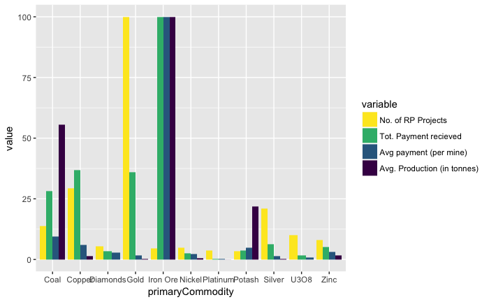

```r
normalize <- function(vec){
    maxVal <- max(vec, na.rm = T)

    out <- numeric()

    for(i in 1:length(vec)){
        out[i] <- (vec[i]/maxVal)*100
    }
    out
}
left_join(snlSum, projectSum, by = "primaryCommodity") %>%
    filter(!is.na(`No. of RP Projects`) & `No. of RP Projects` > 10) %>%
    select(1, 3, 4, 5, 8) %>%
    mutate_at(2:5, normalize) %>%
    gather(key = "variable", value = "value", -1) %>%
    filter(!is.nan(value)) %>%
    mutate(variable = factor(variable, levels = c("No. of RP Projects", "Tot. Payment recieved", "Avg payment (per mine)", "Avg. Production (in tonnes)"))) %>%
    ggplot(., aes(x = primaryCommodity, y = value, fill = variable)) +
    geom_bar(stat = "identity", position = "dodge") +
    scale_fill_viridis(discrete = T, direction = -1)
```

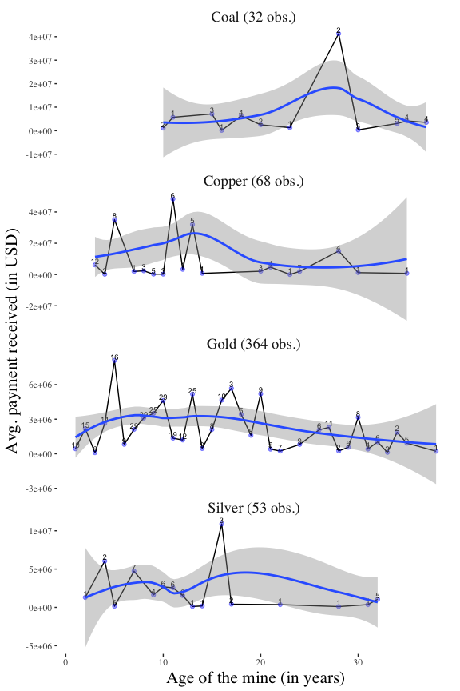

```r
chartData <- projectData %>%
    left_join(., snlTemp, by = "snlPropID") %>%
    mutate(startUpYear = as.numeric(ifelse(startUpYear == "NA", NA, startUpYear))) %>%
    mutate(age = (2018 - (startUpYear)))%>%
    filter(!is.na(age)) %>%
    mutate(ageCat = factor(cut(age, breaks = c(0, 2, 5, 10, 20, 30, 1000)), labels = c("0 to 5", "5 to 10", "10 to 15", "15 to 20", "20 to 30", "Greater than 30"))) %>%
    group_by(primaryCommodity, age) %>%
    filter(projectPayment < quantile(projectPayment, 0.95) & projectPayment > 0 & age < 40) %>%
    mutate(avPay = mean(projectPayment), countAge = n()) %>%
    ungroup() %>%
    group_by(primaryCommodity) %>%
    mutate(countCom = n()) %>%
    filter(countCom > 30) %>%
    ungroup() %>%
    mutate(primaryCommodity = paste0(primaryCommodity, " (",countCom, " obs.) "))
ggplot() +
    geom_line(data = chartData %>%
                  distinct(primaryCommodity, age, avPay), aes(x = age, y = avPay)) +
    geom_point(data = chartData %>%
                  distinct(primaryCommodity, age, avPay), aes(x = age, y = avPay), alpha = 0.4, colour = "blue") +
    geom_text(data = chartData %>%
                  distinct(primaryCommodity, age, avPay, countAge), aes(x = age, y = avPay, label = countAge), vjust = -0.25, size = 2.5) +
    geom_smooth(data = chartData, aes(x = age, y = projectPayment), method = 'loess', level = 0.9) +
    facet_wrap(~primaryCommodity, ncol = 1, scales = "free_y") +
    labs(x = "Age of the mine (in years)", y = "Avg. payment received (in USD)") +
    theme_tufte() +
    theme(legend.title = element_blank(),
          strip.text.x = element_text(size = 14),
          legend.position = "top",
          title = element_text(size = 16),
          legend.text = element_text(size = 12)
          )
```